# Data driven prediction models of energy use of appliances in a low-energy house

The goal of this portfolio is to reproduce some work on predicting the energy usage of a house based on IoT measurements of temperature and humidity and weather observations. The target paper is:

Data driven prediction models of energy use of appliances in a low-energy house. Luis M. Candanedo, Véronique Feldheim, Dominique Deramaix. Energy and Buildings, Volume 140, 1 April 2017, Pages 81-97, ISSN 0378-7788, http://dx.doi.org/10.1016/j.enbuild.2017.01.083.

```python
import pandas as pd
import seaborn as sns
from matplotlib import pyplot as plt
import math
import datetime
from datetime import datetime
%matplotlib inline
```

## Import the data

Importing the data from `energydata_complete.csv` file into the DataFrame `df` using pandas `read_csv` function

```python
df = pd.read_csv('data/energydata_complete.csv')
```

## Observing the data

Calling `df.head()` to observe the data. So we have a rough idea about the attributes, values and types.

```python
df.head()
```

|  | date | Appliances | lights | T1 | RH_1 | T2 | RH_2 | T3 | RH_3 | T4 | ... | T9 | RH_9 | T_out | Press_mm_hg | RH_out | Windspeed | Visibility | Tdewpoint | rv1 | rv2 |
| --- | --- | --- | --- | --- | --- | --- | --- | --- | --- | --- | --- | --- | --- | --- | --- | --- | --- | --- | --- | --- | --- |
| 0 | 2016-01-11 17:00:00 | 60 | 30 | 19.89 | 47.596667 | 19.2 | 44.790000 | 19.79 | 44.730000 | 19.000000 | ... | 17.033333 | 45.53 | 6.600000 | 733.5 | 92.0 | 7.000000 | 63.000000 | 5.3 | 13.275433 | 13.275433 |
| 1 | 2016-01-11 17:10:00 | 60 | 30 | 19.89 | 46.693333 | 19.2 | 44.722500 | 19.79 | 44.790000 | 19.000000 | ... | 17.066667 | 45.56 | 6.483333 | 733.6 | 92.0 | 6.666667 | 59.166667 | 5.2 | 18.606195 | 18.606195 |
| 2 | 2016-01-11 17:20:00 | 50 | 30 | 19.89 | 46.300000 | 19.2 | 44.626667 | 19.79 | 44.933333 | 18.926667 | ... | 17.000000 | 45.50 | 6.366667 | 733.7 | 92.0 | 6.333333 | 55.333333 | 5.1 | 28.642668 | 28.642668 |
| 3 | 2016-01-11 17:30:00 | 50 | 40 | 19.89 | 46.066667 | 19.2 | 44.590000 | 19.79 | 45.000000 | 18.890000 | ... | 17.000000 | 45.40 | 6.250000 | 733.8 | 92.0 | 6.000000 | 51.500000 | 5.0 | 45.410389 | 45.410389 |
| 4 | 2016-01-11 17:40:00 | 60 | 40 | 19.89 | 46.333333 | 19.2 | 44.530000 | 19.79 | 45.000000 | 18.890000 | ... | 17.000000 | 45.40 | 6.133333 | 733.9 | 92.0 | 5.666667 | 47.666667 | 4.9 | 10.084097 | 10.084097 |

5 rows × 29 columns

By calling the `shape` function, we can see that there is 19,735 number of rows (data) and 29 columns (attributes).

```python
df.shape
```

```
(19735, 29)
```

## Forming DataFrame

We need to form a new DataFrame `df_dateNappli` with right attributes to plot graphs.

We take `date` and `Appliances` attributes into the `df_dateNappli` DataFrame. When we created the new DataFrame, `date` attribute's type has been changed to objects. Now we need to convert it back to `datetime64[ns]` type. Then we will set the new DataFrame's index as `date`.

```python
df_dateNappli = pd.DataFrame({'date': df['date'], 'Appliances': df['Appliances']})
df_dateNappli.date=df_dateNappli.date.astype('datetime64[ns]')
df_dateNappli.set_index('date', inplace=True)
```

## Appliances energy consumption measurement for the whole period

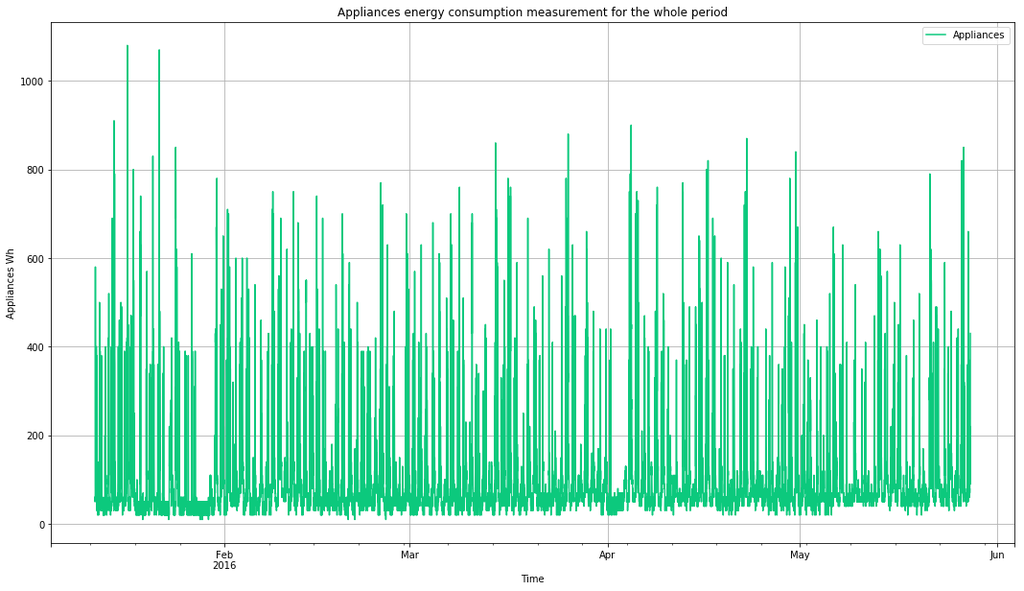

```python
df_dateNappli.plot(color="#0cc97d")
plt.rcParams["figure.figsize"] = (18,10)
plt.grid()
plt.title('Appliances energy consumption measurement for the whole period')
plt.xlabel('Time')
plt.ylabel('Appliances Wh')
plt.show()
```

Here it shows the energy consumption profile for the period. The energy consumption profile shows a high variability. We can see from here that the highest Appliances Wh is around 1100 and it was in January month. Also, we can see that, at the end of January, February and March, there were big fall down in Appliances useage.

## Appliances energy consumption measurement - A closer look at the first week of data.

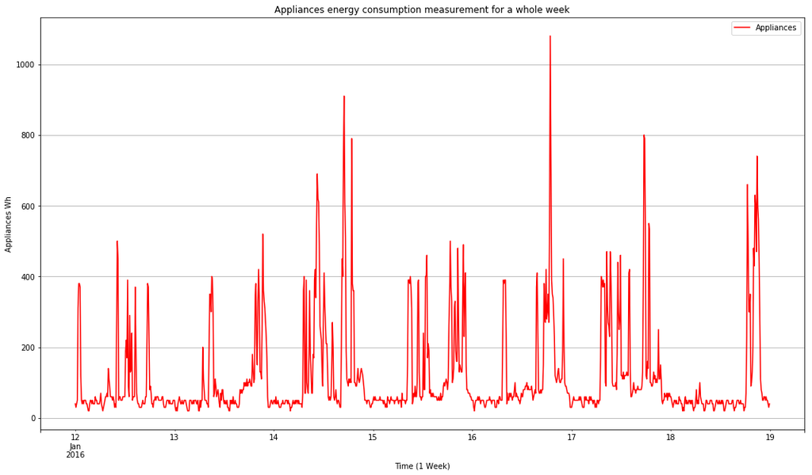

```python
df_dateNappli['2016-01-12':'2016-01-18'].plot(color="red")
plt.rcParams["figure.figsize"] = (18,10)
plt.title('Appliances energy consumption measurement for a whole week')
plt.grid()
plt.xlabel('Time (1 Week)')
plt.ylabel('Appliances Wh')
plt.show()
```

We can see from here that the highest Appliances Wh is around 1100 and it was on 16th of January. Also, we can see that, it follows a bit of a pattern though it is not a strong one.

## Appliances energy consumption distribution. The histogram shows the frequency of energy consumption in the interval.

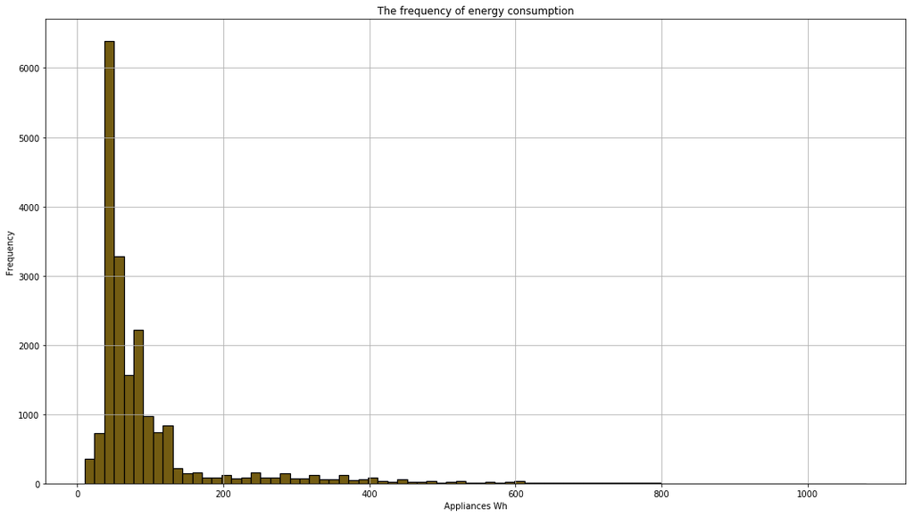

```python
plt.hist(df_dateNappli.Appliances, bins=80, edgecolor='black', linewidth=1.2)
plt.rcParams["figure.figsize"] = (18,10)
plt.title('The frequency of energy consumption')
plt.grid()
plt.xlabel('Appliances Wh')
plt.ylabel('Frequency')
plt.show()
```

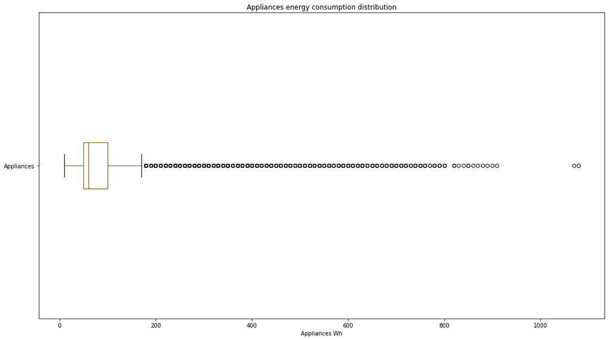

```python
ax = df_dateNappli.Appliances.plot.box(vert=False)
plt.xlabel('Appliances Wh')
plt.title('Appliances energy consumption distribution')
plt.show()
```

## Data sets and exploratory analysis

The combined data set is split in training and test validation. 75% of the data is used for the training of the models and the rest is used for testing. Training and test sets were already given. So, we are just importing them by reading csv.

```python
train = pd.read_csv('data/training.csv')
test = pd.read_csv('data/testing.csv')
```

We take some attributes (not all of them) to see if there is any correlations in between them. Relationship between the energy consumption of appliances with: lights, T1, RH1, T2, RH2, T3, RH3. T1 and RH1 correspond to the kitchen conditions; T2 and RH2 correspond to the living room conditions.

```python
df_relations = pd.DataFrame({'Appliances': train['Appliances'], 'lights': train['lights'],
                             'T1': train['T1'], 'RH_1': train['RH_1'],
                             'T2': train['T2'], 'RH_2': train['RH_2'],
                             'T3': train['T3'], 'RH_3': train['RH_3']})
```

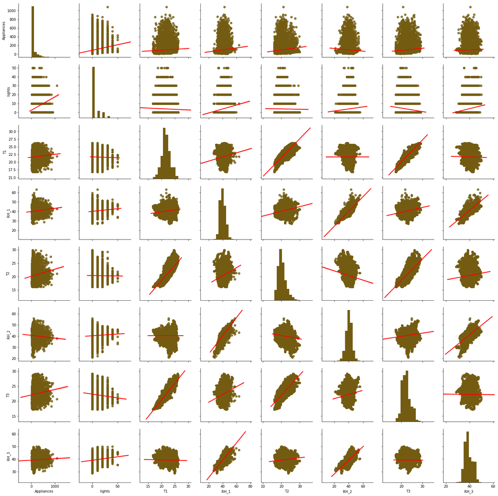

```python
g = sns.pairplot(df_relations, kind="reg", plot_kws={'line_kws':{'color':'red'}})
```

This figure presents pair plots showing the relationships between all the variables with the energy consumption of appliances in the training set. These figures were created with the `Seaborn Pairplot`. These Figures show the bivariate scatter plots below and above the diagonal, histogram plots along the diagonal. It is a measure of the linear dependence between two variables. In red the linear regression fits are shown for each pair. In this figure, it shows that there is a positive correlation between the energy consumption of appliances and lights. Also, there is a positive correlation between appliances and T2. For the indoor temperatures, the correlations are high as expected, since the ventilation is driven by the HRV unit and minimizes air temperature differences between rooms. For example, a positive correlation is found with T1 and T3.

## Observing some other correlations between features.

Again, We take some attributes (not all of them) to see if there is any correlations in between them.

```python
df_relations_2 = pd.DataFrame({'Appliances': train['Appliances'],
                             'T4': train['T4'], 'RH_4': train['RH_4'],
                             'T5': train['T5'], 'RH_5': train['RH_5'],
                             'T6': train['T6'], 'RH_6': train['RH_6']})
```

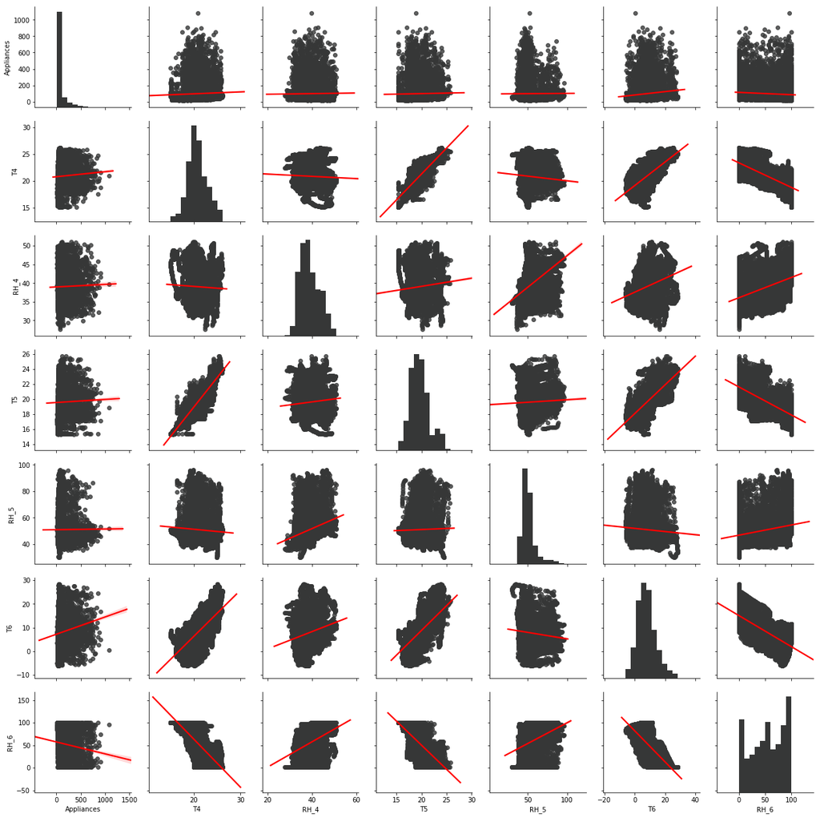

```python
col_list = ["dark grey"]
col_list_palette = sns.xkcd_palette(col_list)
sns.set_palette(col_list_palette)
g = sns.pairplot(df_relations_2, kind="reg", plot_kws={'line_kws':{'color':'red'}})
```

This pairplot showing relationships between the energy consumption of appliances with: T4, RH4, T5, RH5, T6, RH6. T4 and RH4 correspond to the office conditions; T5 and RH5 correspond to the bathroom conditions, and T6 and RH6 correspond to the outdoor conditions.

```python
df_relations_3 = pd.DataFrame({'Appliances': train['Appliances'],
                             'T7': train['T7'], 'RH_7': train['RH_7'],
                             'T8': train['T8'], 'RH_8': train['RH_8'],
                             'T9': train['T9'], 'RH_9': train['RH_9']})
```

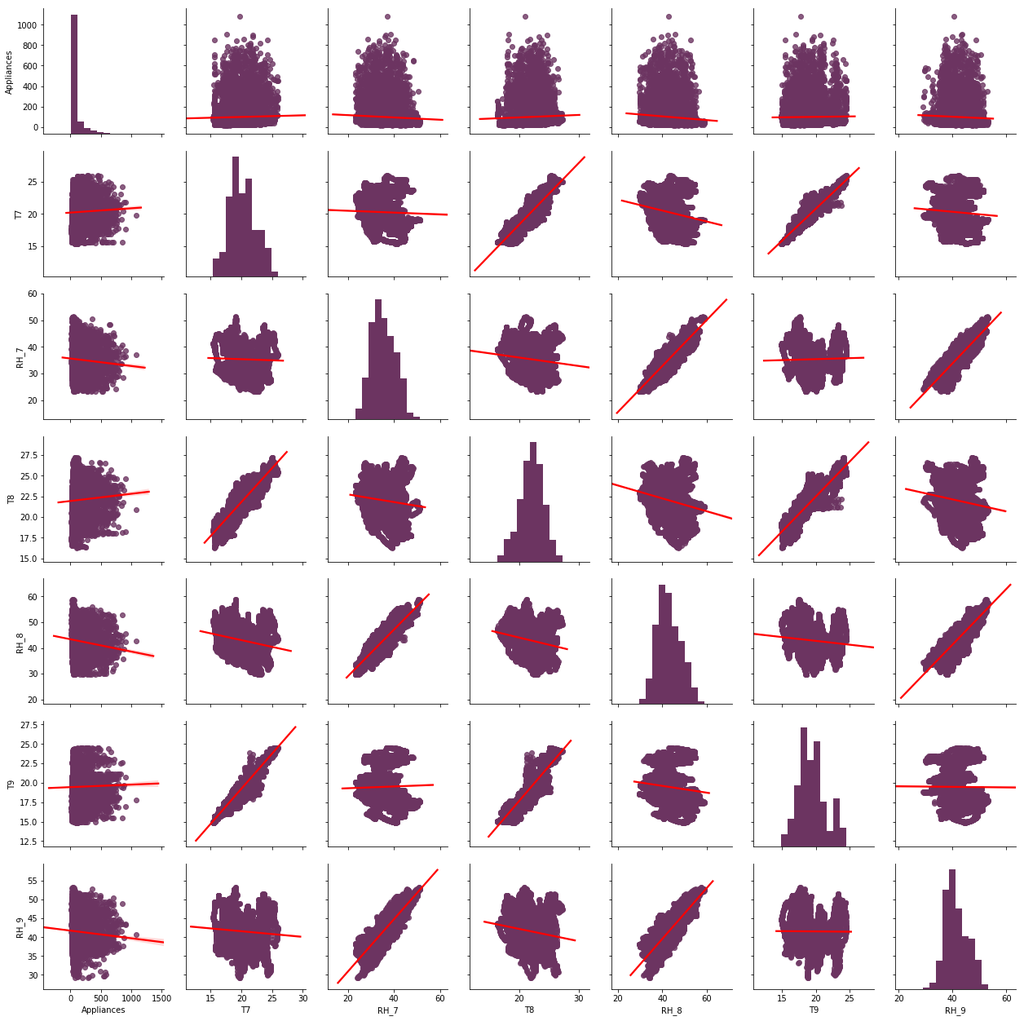

```python
col_list = ["grape"]
col_list_palette = sns.xkcd_palette(col_list)
sns.set_palette(col_list_palette)
g = sns.pairplot(df_relations_3, kind="reg", plot_kws={'line_kws':{'color':'red'}})
```

This pairplot showing relationships between the energy consump- tion of appliances with: T7, RH7,T8, RH8, T9,RH9. T7 and RH7 correspond to the ironing room conditions, T8 and RH8 correspond to room 2, T9 and RH9 correspond to the main room.

```python
df_relations_4 = pd.DataFrame({'Appliances': train['Appliances'],
                             'T_out': train['T_out'], 'Press_mm_hg': train['Press_mm_hg'],
                             'RH_out': train['RH_out'], 'Windspeed': train['Windspeed'],
                             'Visibility': train['Visibility'], 'Tdewpoint': train['Tdewpoint'],
                             'NSM': train['NSM'], 'T6': train['T6']})
```

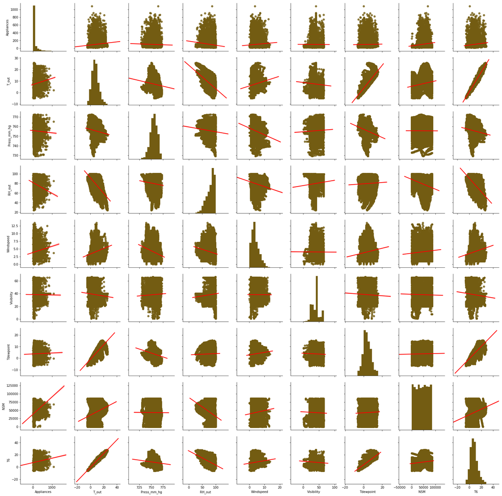

```python
col_list = ["mud"]
col_list_palette = sns.xkcd_palette(col_list)
sns.set_palette(col_list_palette)
g = sns.pairplot(df_relations_4, kind="reg", plot_kws={'line_kws':{'color':'red'}})
```

This pairplot showing relationships between the energy con- sumption of appliances with: T out, Pressure, RH out, Windspeed, Visibility, TDewpoint, NSM and T6.

# Heatmap for Hourly Energy Consumption

Four hourly heatmaps were created for four consecutive weeks of data to identify any time trends.

```python
# Temporary dataframe to access heatmap information
df_heat_temp = pd.DataFrame({'idx': df['date'], 'date': df['date'], 'Appliances': df['Appliances']})
df_heat_temp.date=df_heat_temp.date.astype('str')
df_heat_temp.idx=df_heat_temp.idx.astype('datetime64[ns]')
df_heat_temp.set_index('idx', inplace=True)
```

```python
# Function to generate heatmap dictionary of dictionaries (2D Dictionary)
def heatGen(data):
    dic = dict()
    days_lst = ['Monday', 'Tuesday', 'Wednesday', 'Thursday', 'Friday', 'Saturday', 'Sunday']
    time_lst = [x for x in range(0,24)]
    for i in range(0, len(time_lst)):
        dic[i]={}

    for i in range(0, len(time_lst)):
        for x in days_lst:
            dic[i][x]=0

    for i in range(0, data.shape[0]):
        dic[datetime.strptime(data.iloc[i]['date'], "%Y-%m-%d %H:%M:%S").hour][days_lst[datetime.strptime(data.iloc[i]['date'], "%Y-%m-%d %H:%M:%S").weekday()]] += data.iloc[i]['Appliances']
    return dic
```

```python
# Temporary dictionaries for generating heatmaps for four consecutive weeks
heatmap_dic_w1 = heatGen(df_heat_temp['2016-01-11':'2016-01-17'])
heatmap_dic_w2 = heatGen(df_heat_temp['2016-01-18':'2016-01-24'])
heatmap_dic_w3 = heatGen(df_heat_temp['2016-01-25':'2016-01-31'])
heatmap_dic_w4 = heatGen(df_heat_temp['2016-02-01':'2016-02-07'])
```

```python
# Heatmap dataframes for four consecutive weeks
heat_df_w1 = pd.DataFrame({'Saturday': [heatmap_dic_w1[x]['Saturday'] for x in heatmap_dic_w1],
                       'Sunday': [heatmap_dic_w1[x]['Sunday'] for x in heatmap_dic_w1],
                       'Monday': [heatmap_dic_w1[x]['Monday'] for x in heatmap_dic_w1],
                       'Tuesday': [heatmap_dic_w1[x]['Tuesday'] for x in heatmap_dic_w1],
                       'Wednesday': [heatmap_dic_w1[x]['Wednesday'] for x in heatmap_dic_w1],
                       'Thursday': [heatmap_dic_w1[x]['Thursday'] for x in heatmap_dic_w1],
                       'Friday': [heatmap_dic_w1[x]['Friday'] for x in heatmap_dic_w1],})

heat_df_w2 = pd.DataFrame({'Saturday': [heatmap_dic_w2[x]['Saturday'] for x in heatmap_dic_w2],
                       'Sunday': [heatmap_dic_w2[x]['Sunday'] for x in heatmap_dic_w2],
                       'Monday': [heatmap_dic_w2[x]['Monday'] for x in heatmap_dic_w2],
                       'Tuesday': [heatmap_dic_w2[x]['Tuesday'] for x in heatmap_dic_w2],
                       'Wednesday': [heatmap_dic_w2[x]['Wednesday'] for x in heatmap_dic_w2],
                       'Thursday': [heatmap_dic_w2[x]['Thursday'] for x in heatmap_dic_w2],
                       'Friday': [heatmap_dic_w2[x]['Friday'] for x in heatmap_dic_w2],})

heat_df_w3 = pd.DataFrame({'Saturday': [heatmap_dic_w3[x]['Saturday'] for x in heatmap_dic_w3],
                       'Sunday': [heatmap_dic_w3[x]['Sunday'] for x in heatmap_dic_w3],
                       'Monday': [heatmap_dic_w3[x]['Monday'] for x in heatmap_dic_w3],
                       'Tuesday': [heatmap_dic_w3[x]['Tuesday'] for x in heatmap_dic_w3],
                       'Wednesday': [heatmap_dic_w3[x]['Wednesday'] for x in heatmap_dic_w3],
                       'Thursday': [heatmap_dic_w3[x]['Thursday'] for x in heatmap_dic_w3],
                       'Friday': [heatmap_dic_w3[x]['Friday'] for x in heatmap_dic_w3],})

heat_df_w4 = pd.DataFrame({'Saturday': [heatmap_dic_w4[x]['Saturday'] for x in heatmap_dic_w4],
                       'Sunday': [heatmap_dic_w4[x]['Sunday'] for x in heatmap_dic_w4],
                       'Monday': [heatmap_dic_w4[x]['Monday'] for x in heatmap_dic_w4],
                       'Tuesday': [heatmap_dic_w4[x]['Tuesday'] for x in heatmap_dic_w4],
                       'Wednesday': [heatmap_dic_w4[x]['Wednesday'] for x in heatmap_dic_w4],
                       'Thursday': [heatmap_dic_w4[x]['Thursday'] for x in heatmap_dic_w4],
                       'Friday': [heatmap_dic_w4[x]['Friday'] for x in heatmap_dic_w4],})
```

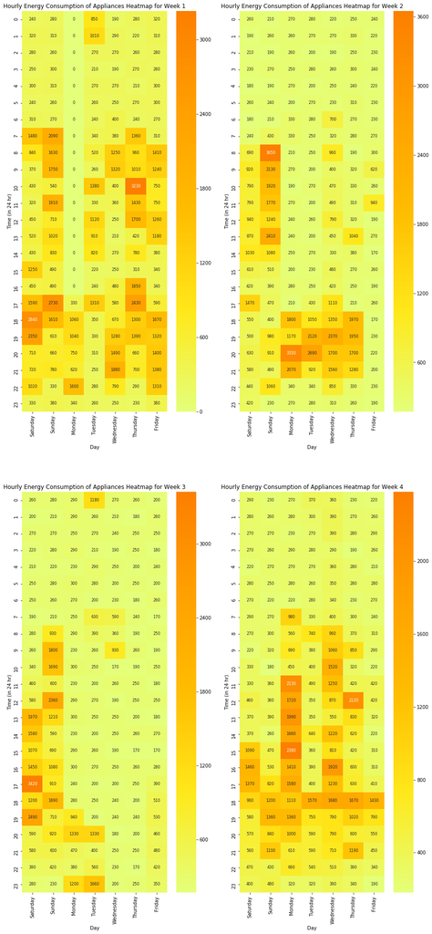

```python
#Multi plot
fig, axes = plt.subplots(2,2, figsize=(15, 34), facecolor='w', edgecolor='k')

#4 heatmaps for energy consumption for four consecutive weeks
sns.heatmap(heat_df_w1, annot=True, fmt='g', annot_kws={"size": 8}, cmap="Wistia", ax=axes[0, 0])
sns.heatmap(heat_df_w2, annot=True, fmt='g', annot_kws={"size": 8}, cmap="Wistia", ax=axes[0, 1])
sns.heatmap(heat_df_w3, annot=True, fmt='g', annot_kws={"size": 8}, cmap="Wistia", ax=axes[1, 0])
sns.heatmap(heat_df_w4, annot=True, fmt='g', annot_kws={"size": 8}, cmap="Wistia", ax=axes[1, 1])
d = 1
for i in range(2):
    for j in range(2):
        axes[i,j].set_title("Hourly Energy Consumption of Appliances Heatmap for Week "+str(d))
        axes[i,j].set_xlabel("Day")
        axes[i,j].set_ylabel("Time (in 24 hr)")
        d += 1

plt.show()
```

As can be clearly seen, there is a strong time component in the energy consumption pattern. The energy consumption starts to rise around 7-8 am in the morning. Then around noon, there are energy load surges. The energy demand also increases around 6 pm. There is no clear pattern regarding the day of the week.

## Data features filtering and importance

Since the dataset contains several features or parameters and considering that the airport weather station is not at the same location as the house, it is desirable to find out which parameters are the most important and which ones do not improve the prediction of the appliances’ energy consumption. For this task the **sklearn RFE function** is used to select all the relevant variables. this feature or variable selection helps in model interpretability and reduces complexity of the model.

Here, we are dividing the sets into 2 part, input and target, so we can train our model with them.

```python
X_train = train.drop(columns=['date', 'Appliances'])
y_train = train[['Appliances']]

X_test = test.drop(columns=['date', 'Appliances'])
y_test = test[['Appliances']]
```

Because of the training purpose, mapping strings into numaric values.

```python
X_train['WeekStatus'] = X_train['WeekStatus'].map({'Weekday': 1, 'Weekend': 0})
X_train['Day_of_week'] = X_train['Day_of_week'].map({'Saturday': 1, 'Sunday': 2, 'Monday': 3,
                                                     'Tuesday': 4, 'Wednesday': 5, 'Thursday': 6, 'Friday': 7})

X_test['WeekStatus'] = X_test['WeekStatus'].map({'Weekday': 1, 'Weekend': 0})
X_test['Day_of_week'] = X_test['Day_of_week'].map({'Saturday': 1, 'Sunday': 2, 'Monday': 3,
                                                     'Tuesday': 4, 'Wednesday': 5, 'Thursday': 6, 'Friday': 7})
```

Dropping the 2 random variables which were introduced earlier by the author because they don't have any predicting power.

```python
X_train.drop(columns=['rv1', 'rv2'], inplace=True)
X_test.drop(columns=['rv1', 'rv2'], inplace=True)
```

We are using Linear Regression to train our model and predict.

```python
from sklearn import linear_model
from sklearn.metrics import r2_score

lr = linear_model.LinearRegression()
lr.fit(X_train, y_train)
pred_trn = lr.predict(X_train)
pred_tst = lr.predict(X_test)
```

This function helps to print out MSE, RMSE and R2 of the model.

```python
from sklearn.metrics import mean_squared_error
def genEvaluation(y, p):
    mse = mean_squared_error(y, p)
    print("MSE: ",mse)
    rmse = math.sqrt(mse)
    print("RMSE: ",rmse)
    r2 = r2_score(y, p)
    print("R2: ", r2)
```

Score with all features

```python
print('Train Set:')
genEvaluation(y_train, pred_trn)

print('Test Set:')
genEvaluation(y_test, pred_tst)
```

```
Train Set:
MSE:  8741.770228298881
RMSE:  93.49743434072873
R2:  0.17318987597948154
Test Set:
MSE:  8753.178546675483
RMSE:  93.55842317330644
R2:  0.15209747399037488
```

### Now we are introducing Recursive Feature Estimation (RFE) to eliminate fetaures which are less important and examine how it impacts on the performance.

```python
from sklearn.feature_selection import RFE

cols = [x for x in X_test.columns.values]
col_size = X_train.shape[1]

for ix in range(1, col_size+1):
    selector = RFE(lr, ix)
    selector = selector.fit(X_train, y_train.values.ravel())

    lst = []
    for i in range(0, len(selector.support_)):
        if selector.support_[i] == True:
            lst.append(cols[i])

    drop_col = []
    for x in cols:
        if x not in lst:
            drop_col.append(x)

    RFE_X_train = X_train.drop(columns=drop_col)
    RFE_X_test = X_test.drop(columns=drop_col)
    lr.fit(RFE_X_train, y_train)
    prd_trn = lr.predict(RFE_X_train)
    prd_tst = lr.predict(RFE_X_test)
    print('Number of best features: ', ix)
    print("Train Set: ")
    genEvaluation(y_train, prd_trn)
    print('')
    print("Test Set: ")
    genEvaluation(y_test, prd_tst)
    print('---------------------------------')
```

```
Number of best features:  1
Train Set:
MSE:  10492.35178015698
RMSE:  102.4321813697091
R2:  0.0076171702002442165

Test Set:
MSE:  10255.387869499948
RMSE:  101.26888895164174
R2:  0.006581525397981403
---------------------------------
Number of best features:  2
Train Set:
MSE:  9994.225060089342
RMSE:  99.97112113050119
R2:  0.05473076440840541

Test Set:
MSE:  9825.56620100739
RMSE:  99.12399407311729
R2:  0.04821747244340402
---------------------------------
Number of best features:  3
Train Set:
MSE:  9968.998279040294
RMSE:  99.84487107027728
R2:  0.05711675230594604

Test Set:
MSE:  9785.660985567923
RMSE:  98.92249989546323
R2:  0.05208300915005948
---------------------------------
Number of best features:  4
Train Set:
MSE:  9632.530772901291
RMSE:  98.14545721989016
R2:  0.0889403684860065

Test Set:
```

[output cut: 253 more lines]

```
MSE:  8779.065222579846
RMSE:  93.69666601635218
R2:  0.14958988457331246
---------------------------------
Number of best features:  28
Train Set:
MSE:  8741.770228298881
RMSE:  93.49743434072873
R2:  0.17318987597948154

Test Set:
MSE:  8753.178546675483
RMSE:  93.55842317330644
R2:  0.15209747399037488
---------------------------------
```

We can see from here, what will be the score of the model when specific features are selected.

## Comparison

In the given paper, they have RMSE score of 93.21 and R2 score of 0.18 in the training set and RMSE score of 93.18 and R2 score of 0.16 in the testing set. With our best features, we have RMSE score of 93.49 and R2 score of 0.17 in the training set and RMSE score of 93.55 and R2 score of 0.15 in the testing set.